# FbBirthdays

Vijay Sathish

Friday, April 17, 2015

### Distribution of your friends’ birth months and days.

How many people share your birthday? Do you know them? (Reserve time with them or save money to buy them a gift!) Which month contains the most number of birthdays? How many birthdays are in each month? Which day of the year has the most number of birthdays? Do you have at least 365 friends that have birthdays on everyday of the year? **********************************************************************

You will need to do some data munging and additional research to complete this task. This task won’t be easy, and you may encounter some unexpected challenges along the way. We hope you learn a lot from it though.

You can expect to spend 30 min or more on this task depending if you use the provided data or obtain your personal data. We also encourage you to use the lubridate package for working with dates. Read over the documentation in RStudio and search for examples online if you need help.

You’ll need to export your Facebooks friends’ birthdays to a csv file. You may need to create a calendar of your Facebook friends? birthdays in a program like Outlook or Gmail and then export the calendar as a csv file.

Once you load the data into R Studio, you can use the strptime() function to extract the birth months and birth days. We recommend looking up the documentation for the function and finding examples online.

### Start

Notes: Working with pre-processed list from instructor notes - Didn’t have to go through all the transformations to get to CSV - No names or year data here, only day and month

```r
# read.csv() and read.table() achieve same results
raw <- read.csv("D:/EDA/R_wd/L3/birthdaysExample.csv", as.is = T, header = T)
str(raw)
```

```
## 'data.frame':    1033 obs. of  1 variable:
##  $ dates: chr  "11/25/14" "6/8/14" "9/12/14" "5/26/14" ...
```

```r
head(raw)
```

```
##      dates
## 1 11/25/14
## 2   6/8/14
## 3  9/12/14
## 4  5/26/14
## 5  2/20/14
## 6  6/19/14
```

```r
dat.in <- read.table("D:/EDA/R_wd/L3/birthdaysExample.csv", header = T, as.is = T)
str(dat.in)
```

```
## 'data.frame':    1033 obs. of  1 variable:
##  $ dates: chr  "11/25/14" "6/8/14" "9/12/14" "5/26/14" ...
```

```r
head(dat.in)
```

```
##      dates
## 1 11/25/14
## 2   6/8/14
## 3  9/12/14
## 4  5/26/14
## 5  2/20/14
## 6  6/19/14
```

```r
# Use lubridate and this actually becomes a breeze
# http://cran.r-project.org/web/packages/lubridate/vignettes/lubridate.html
library('lubridate')
dat.gd <- mdy(dat.in$dates)
str(dat.gd)
```

```
##  POSIXct[1:1033], format: "2014-11-25" "2014-06-08" "2014-09-12" "2014-05-26" ...
```

```r
head(dat.gd)
```

```
## [1] "2014-11-25 UTC" "2014-06-08 UTC" "2014-09-12 UTC" "2014-05-26 UTC"
## [5] "2014-02-20 UTC" "2014-06-19 UTC"
```

```r
# Finally extract out the month, date and years and we are ready to go
dat.df <- data.frame(Value = dat.gd, Year = year(dat.gd), Month = month(dat.gd), Day = day(dat.gd))
str(dat.df)
```

```
## 'data.frame':    1033 obs. of  4 variables:
##  $ Value: POSIXct, format: "2014-11-25" "2014-06-08" ...
##  $ Year : num  2014 2014 2014 2014 2014 ...
##  $ Month: num  11 6 9 5 2 6 10 10 7 9 ...
##  $ Day  : int  25 8 12 26 20 19 10 22 6 20 ...
```

```r
head(dat.df)
```

```
##        Value Year Month Day
## 1 2014-11-25 2014    11  25
## 2 2014-06-08 2014     6   8
## 3 2014-09-12 2014     9  12
## 4 2014-05-26 2014     5  26
## 5 2014-02-20 2014     2  20
## 6 2014-06-19 2014     6  19
```

Response: Note that read.csv() or read.table() will both work, but important to set as.is = T to prevent from getting it converted into a factors and retain as chr

### Lets see if we can use separate() from tidyr to achieve the same thing!

```r
data.untidy <- read.table("D:/EDA/R_wd/L3/birthdaysExample.csv", header = T, as.is = T)
str(data.untidy)
```

```
## 'data.frame':    1033 obs. of  1 variable:
##  $ dates: chr  "11/25/14" "6/8/14" "9/12/14" "5/26/14" ...
```

```r
library(tidyr)
data.tidy <- separate(data = data.untidy, col = dates, into = c("Month", "Date", "Year"), sep = "/")
# Conversion to integer from character
data.tidy$Month <- as.integer(data.tidy$Month)
data.tidy$Date <- as.integer(data.tidy$Date)
data.tidy$Year <- as.integer(data.tidy$Year)
str(data.tidy)
```

```
## 'data.frame':    1033 obs. of  3 variables:
##  $ Month: int  11 6 9 5 2 6 10 10 7 9 ...
##  $ Date : int  25 8 12 26 20 19 10 22 6 20 ...
##  $ Year : int  14 14 14 14 14 14 14 14 14 14 ...
```

Notes: In fact, we can! And this one is actually more intuitive to me than using lubridate()

### Some very basic plots

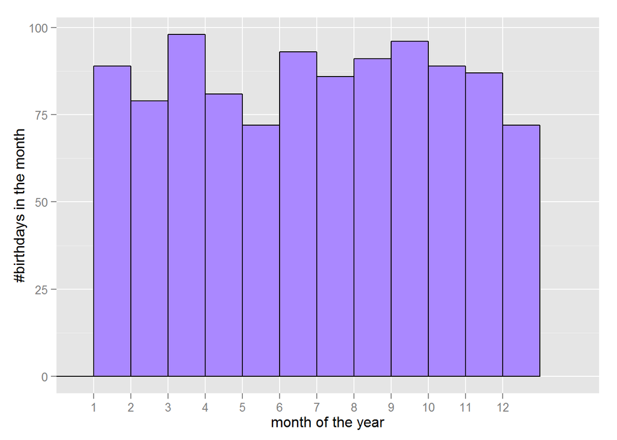

```r
library(ggplot2)

qplot(data = dat.df, x = Month,
      color = I('black'), fill = I('#aa88ff'), binwidth = 1,
      xlab = 'month of the year', ylab = '#birthdays in the month') +
  scale_x_discrete(breaks = c(1:12))
```

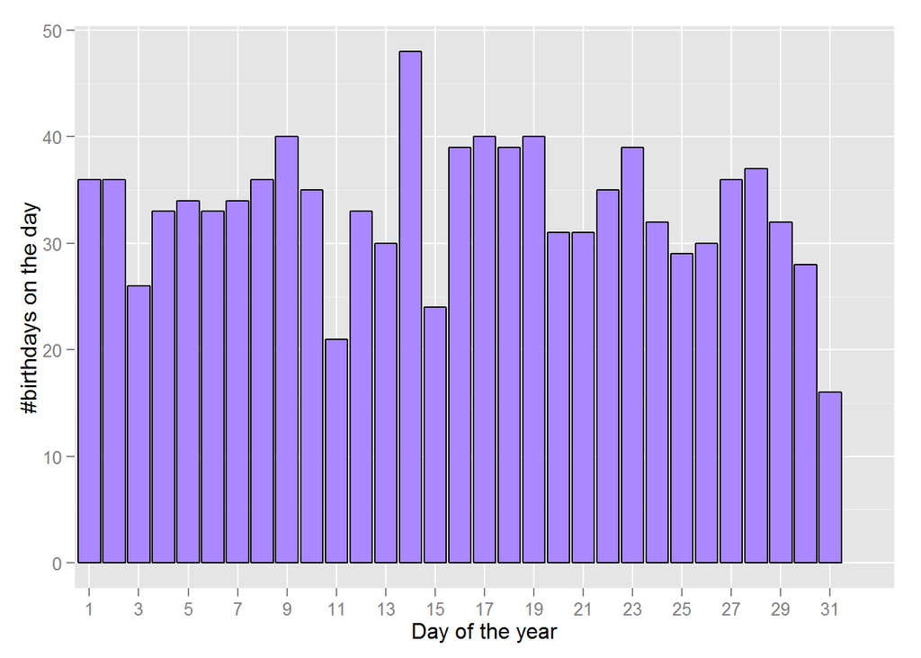

```r
qplot(data = dat.df, x = Day,
      color = I('black'), fill = I('#aa88ff'), binwidth = 1,
      xlab = 'Day of the year', ylab = '#birthdays on the day') +
  scale_x_discrete(breaks = seq(1, 31, 2))
```